# Project: TMDB Movies Data Analysis

- Introduction
- Environment Preparation
- Data Wrangling
- Exploratory Data Analysis
- Conclusions
- References

## Introduction

### Dataset Description

> The data I chose is TMDb movie data which are cleaned from original data on Kaggle website. This data contains some information about nearly ten thousand movies collected from The Movie Database. below there is a table shows the columns names in datasest and their significance:

| Columne Name | Signicance |
| --- | --- |
| id | A unique identifier for each movie. |
| imdb_id | the movie identifier as in the IMDB dataset. |
| popularity | A numeric quantity specifying the movie popularity. |
| budget | The budget in which the movie was made. |
| revenue | The worldwide revenue generated by the movie. |
| original_title | The title of the movie before translation or adaptation. |
| cast | The name of lead and supporting actors. |
| homepage | A link to the homepage of the movie. |
| director | The name of the film director |
| tagline | A line describe the message of the film. |
| keywords | The keywords or tags related to the movie. |
| overview | A brief description of the movie. |
| runtime | The running time of the movie in minutes. |
| genres | The genre of the movie,drama, Action, Comedy , etc. |
| production_companies | The production house of the movie. |
| release_date | The date on which it was released. |
| vote_count | the count of votes recieved. |
| vote_average | average ratings the movie recieved. |
| release_year | The year on which film was released. |
| budget_adj | show the budget of the associated movie in terms of 2010 dollars, accounting for inflation over time. |
| revenue_adj | show revenue of the associated movie in terms of 2010 dollars, accounting for inflation over time. |

### Question(s) for Analysis

#### The main questions i will build my anlalysis around it:

> - What are relations between popularity, budget and rating?
> - What are the most succesful movies(in earnings)?
> - Who is the Director produced the best movies in 2010?

## Environment Preparation

> First I will import some useful packages which are:
> - Numpy: a library for Python adding support for large, multi-dimensional arrays and matrices, along with a large collection of high-level mathematical functions to operate on these arrays.
> - Pandas: a library for Python offers data structures and operations for manipulating numerical tables and time series.
> - Matplotlib: Matplotlib is a plotting library for Python and its numerical mathematics extension NumPy.
> - Seaborn: a Python data visualization library based on matplotlib and provides a high-level interface for drawing attractive and informative statistical graphics.

```python
# Upgrade pandas to use dataframe.explode() function.
!pip install --upgrade pandas==0.25.0
```

```python
#importing libraries
import numpy as np
import pandas as pd
import matplotlib.pyplot as plt
import seaborn as sns
% matplotlib inline
sns.set()
```

## Data Wrangling

> In this section I will load my data and take a look of it. Then I will get deeper by exploring the data content to clean it by checking:
> - Incorrect data types
> - Missing data
> - Duplicated values
> - Unwanted columns in my analysis
> - Structural problems
> - Mismatch number of records.

```python
#loading dataset and an overview
tmdb_df = pd.read_csv('tmdb_movies.csv')
tmdb_df.head()
```

|  | id | imdb_id | popularity | budget | revenue | original_title | cast | homepage | director | tagline | ... | overview | runtime | genres | production_companies | release_date | vote_count | vote_average | release_year | budget_adj | revenue_adj |
| --- | --- | --- | --- | --- | --- | --- | --- | --- | --- | --- | --- | --- | --- | --- | --- | --- | --- | --- | --- | --- | --- |
| 0 | 135397 | tt0369610 | 32.985763 | 150000000 | 1513528810 | Jurassic World | Chris Pratt\|Bryce Dallas Howard\|Irrfan Khan\|Vi... | http://www.jurassicworld.com/ | Colin Trevorrow | The park is open. | ... | Twenty-two years after the events of Jurassic ... | 124 | Action\|Adventure\|Science Fiction\|Thriller | Universal Studios\|Amblin Entertainment\|Legenda... | 6/9/15 | 5562 | 6.5 | 2015 | 1.379999e+08 | 1.392446e+09 |
| 1 | 76341 | tt1392190 | 28.419936 | 150000000 | 378436354 | Mad Max: Fury Road | Tom Hardy\|Charlize Theron\|Hugh Keays-Byrne\|Nic... | http://www.madmaxmovie.com/ | George Miller | What a Lovely Day. | ... | An apocalyptic story set in the furthest reach... | 120 | Action\|Adventure\|Science Fiction\|Thriller | Village Roadshow Pictures\|Kennedy Miller Produ... | 5/13/15 | 6185 | 7.1 | 2015 | 1.379999e+08 | 3.481613e+08 |
| 2 | 262500 | tt2908446 | 13.112507 | 110000000 | 295238201 | Insurgent | Shailene Woodley\|Theo James\|Kate Winslet\|Ansel... | http://www.thedivergentseries.movie/#insurgent | Robert Schwentke | One Choice Can Destroy You | ... | Beatrice Prior must confront her inner demons ... | 119 | Adventure\|Science Fiction\|Thriller | Summit Entertainment\|Mandeville Films\|Red Wago... | 3/18/15 | 2480 | 6.3 | 2015 | 1.012000e+08 | 2.716190e+08 |
| 3 | 140607 | tt2488496 | 11.173104 | 200000000 | 2068178225 | Star Wars: The Force Awakens | Harrison Ford\|Mark Hamill\|Carrie Fisher\|Adam D... | http://www.starwars.com/films/star-wars-episod... | J.J. Abrams | Every generation has a story. | ... | Thirty years after defeating the Galactic Empi... | 136 | Action\|Adventure\|Science Fiction\|Fantasy | Lucasfilm\|Truenorth Productions\|Bad Robot | 12/15/15 | 5292 | 7.5 | 2015 | 1.839999e+08 | 1.902723e+09 |
| 4 | 168259 | tt2820852 | 9.335014 | 190000000 | 1506249360 | Furious 7 | Vin Diesel\|Paul Walker\|Jason Statham\|Michelle ... | http://www.furious7.com/ | James Wan | Vengeance Hits Home | ... | Deckard Shaw seeks revenge against Dominic Tor... | 137 | Action\|Crime\|Thriller | Universal Pictures\|Original Film\|Media Rights ... | 4/1/15 | 2947 | 7.3 | 2015 | 1.747999e+08 | 1.385749e+09 |

5 rows × 21 columns

```python
# Looking for data information to check missing values and incorrect data types and needed columns.
tmdb_df.info()
```

```
<class 'pandas.core.frame.DataFrame'>
RangeIndex: 10866 entries, 0 to 10865
Data columns (total 21 columns):
id                      10866 non-null int64
imdb_id                 10856 non-null object
popularity              10866 non-null float64
budget                  10866 non-null int64
revenue                 10866 non-null int64
original_title          10866 non-null object
cast                    10790 non-null object
homepage                2936 non-null object
director                10822 non-null object
tagline                 8042 non-null object
keywords                9373 non-null object
overview                10862 non-null object
runtime                 10866 non-null int64
genres                  10843 non-null object
production_companies    9836 non-null object
release_date            10866 non-null object
vote_count              10866 non-null int64
vote_average            10866 non-null float64
release_year            10866 non-null int64
budget_adj              10866 non-null float64
revenue_adj             10866 non-null float64
dtypes: float64(4), int64(6), object(11)
memory usage: 1.7+ MB
```

```python
#checking Mismatch number of records and zeroes values.
tmdb_df.describe()
```

|  | id | popularity | budget | revenue | runtime | vote_count | vote_average | release_year | budget_adj | revenue_adj |
| --- | --- | --- | --- | --- | --- | --- | --- | --- | --- | --- |
| count | 10866.000000 | 10866.000000 | 1.086600e+04 | 1.086600e+04 | 10866.000000 | 10866.000000 | 10866.000000 | 10866.000000 | 1.086600e+04 | 1.086600e+04 |
| mean | 66064.177434 | 0.646441 | 1.462570e+07 | 3.982332e+07 | 102.070863 | 217.389748 | 5.974922 | 2001.322658 | 1.755104e+07 | 5.136436e+07 |
| std | 92130.136561 | 1.000185 | 3.091321e+07 | 1.170035e+08 | 31.381405 | 575.619058 | 0.935142 | 12.812941 | 3.430616e+07 | 1.446325e+08 |
| min | 5.000000 | 0.000065 | 0.000000e+00 | 0.000000e+00 | 0.000000 | 10.000000 | 1.500000 | 1960.000000 | 0.000000e+00 | 0.000000e+00 |
| 25% | 10596.250000 | 0.207583 | 0.000000e+00 | 0.000000e+00 | 90.000000 | 17.000000 | 5.400000 | 1995.000000 | 0.000000e+00 | 0.000000e+00 |
| 50% | 20669.000000 | 0.383856 | 0.000000e+00 | 0.000000e+00 | 99.000000 | 38.000000 | 6.000000 | 2006.000000 | 0.000000e+00 | 0.000000e+00 |
| 75% | 75610.000000 | 0.713817 | 1.500000e+07 | 2.400000e+07 | 111.000000 | 145.750000 | 6.600000 | 2011.000000 | 2.085325e+07 | 3.369710e+07 |
| max | 417859.000000 | 32.985763 | 4.250000e+08 | 2.781506e+09 | 900.000000 | 9767.000000 | 9.200000 | 2015.000000 | 4.250000e+08 | 2.827124e+09 |

```python
#number of missing values in each row
tmdb_df.isnull().sum()
```

```
id                         0
imdb_id                   10
popularity                 0
budget                     0
revenue                    0
original_title             0
cast                      76
homepage                7930
director                  44
tagline                 2824
keywords                1493
overview                   4
runtime                    0
genres                    23
production_companies    1030
release_date               0
vote_count                 0
vote_average               0
release_year               0
budget_adj                 0
revenue_adj                0
dtype: int64
```

```python
#checking for duplicated values
tmdb_df.duplicated().sum()
```

```
1
```

```python
#checking for data types
tmdb_df.dtypes
```

```
id                        int64
imdb_id                  object
popularity              float64
budget                    int64
revenue                   int64
original_title           object
cast                     object
homepage                 object
director                 object
tagline                  object
keywords                 object
overview                 object
runtime                   int64
genres                   object
production_companies     object
release_date             object
vote_count                int64
vote_average            float64
release_year              int64
budget_adj              float64
revenue_adj             float64
dtype: object
```

```python
#calculate number of zeroes values in budget columne
sum(tmdb_df['budget']==0)
```

```
5696
```

```python
#calculate number of zeroes values in revenue columne
sum(tmdb_df['revenue']==0)
```

```
6016
```

```python
#calculate number of zeroes values in revenue columne
sum(tmdb_df['runtime']==0)
```

```
31
```

### The limitations of first wrangling process

- I found there are alot of missing values need to handle in: imdb_id,homepage, cast, director, tagline, keywords, overview, genres, and production_companies.
- There are many columns we don't need in our anlyasis like :(imdb_id,tagline,homepage,keywords, budget_adj,revenue_adj)
- Fortunately, we have just one duplicated value
- release date column incorrect format.
- there are movies with zero budget value and zero revenue value, means there values have not been recorded.
- movies with zero runtime value.

### Data Cleaning

In this section I will handle the limitations i discovered from last step so i will go through this steps:

1. correct data types
2. droping unwanted columns
3. handling missing data rows
4. delete duplicated rows
5. handling zeroes values in budget and runtime columns

```python
#1.convert type of data in release date columne and checking.
tmdb_df.release_date = pd.to_datetime(tmdb_df['release_date'])
tmdb_df.dtypes
```

```
id                               int64
imdb_id                         object
popularity                     float64
budget                           int64
revenue                          int64
original_title                  object
cast                            object
homepage                        object
director                        object
tagline                         object
keywords                        object
overview                        object
runtime                          int64
genres                          object
production_companies            object
release_date            datetime64[ns]
vote_count                       int64
vote_average                   float64
release_year                     int64
budget_adj                     float64
revenue_adj                    float64
dtype: object
```

```python
#2. I will drop unwanted columns
tmdb_df.drop(['imdb_id','tagline','homepage','keywords','budget_adj','revenue_adj'],axis= 1 ,inplace = True )
tmdb_df.head()
```

|  | id | popularity | budget | revenue | original_title | cast | director | overview | runtime | genres | production_companies | release_date | vote_count | vote_average | release_year |
| --- | --- | --- | --- | --- | --- | --- | --- | --- | --- | --- | --- | --- | --- | --- | --- |
| 0 | 135397 | 32.985763 | 150000000 | 1513528810 | Jurassic World | Chris Pratt\|Bryce Dallas Howard\|Irrfan Khan\|Vi... | Colin Trevorrow | Twenty-two years after the events of Jurassic ... | 124 | Action\|Adventure\|Science Fiction\|Thriller | Universal Studios\|Amblin Entertainment\|Legenda... | 2015-06-09 | 5562 | 6.5 | 2015 |
| 1 | 76341 | 28.419936 | 150000000 | 378436354 | Mad Max: Fury Road | Tom Hardy\|Charlize Theron\|Hugh Keays-Byrne\|Nic... | George Miller | An apocalyptic story set in the furthest reach... | 120 | Action\|Adventure\|Science Fiction\|Thriller | Village Roadshow Pictures\|Kennedy Miller Produ... | 2015-05-13 | 6185 | 7.1 | 2015 |
| 2 | 262500 | 13.112507 | 110000000 | 295238201 | Insurgent | Shailene Woodley\|Theo James\|Kate Winslet\|Ansel... | Robert Schwentke | Beatrice Prior must confront her inner demons ... | 119 | Adventure\|Science Fiction\|Thriller | Summit Entertainment\|Mandeville Films\|Red Wago... | 2015-03-18 | 2480 | 6.3 | 2015 |
| 3 | 140607 | 11.173104 | 200000000 | 2068178225 | Star Wars: The Force Awakens | Harrison Ford\|Mark Hamill\|Carrie Fisher\|Adam D... | J.J. Abrams | Thirty years after defeating the Galactic Empi... | 136 | Action\|Adventure\|Science Fiction\|Fantasy | Lucasfilm\|Truenorth Productions\|Bad Robot | 2015-12-15 | 5292 | 7.5 | 2015 |
| 4 | 168259 | 9.335014 | 190000000 | 1506249360 | Furious 7 | Vin Diesel\|Paul Walker\|Jason Statham\|Michelle ... | James Wan | Deckard Shaw seeks revenge against Dominic Tor... | 137 | Action\|Crime\|Thriller | Universal Pictures\|Original Film\|Media Rights ... | 2015-04-01 | 2947 | 7.3 | 2015 |

```python
#checking the data shape
tmdb_df.shape
```

```
(10866, 15)
```

```python
#checking messing values to know if we can drop it or it will affect on our anlysis quality.
tmdb_df.isnull().sum()
```

```
id                         0
popularity                 0
budget                     0
revenue                    0
original_title             0
cast                      76
director                  44
overview                   4
runtime                    0
genres                    23
production_companies    1030
release_date               0
vote_count                 0
vote_average               0
release_year               0
dtype: int64
```

```python
#3. droping missing value
tmdb_df.dropna(inplace = True)
```

```python
#checking our droping step
tmdb_df.isnull().sum()
```

```
id                      0
popularity              0
budget                  0
revenue                 0
original_title          0
cast                    0
director                0
overview                0
runtime                 0
genres                  0
production_companies    0
release_date            0
vote_count              0
vote_average            0
release_year            0
dtype: int64
```

```python
#looking at the our new data shape
tmdb_df.shape
```

```
(9773, 15)
```

```python
#4. drop duplicated rows and check the step
tmdb_df.drop_duplicates(inplace = True)
tmdb_df.duplicated().sum()
```

```
0
```

```python
#5. checking rows with zeroes values in runtime columne
runtime_zeroes = tmdb_df['runtime'] == 0
tmdb_df[runtime_zeroes]
```

|  | id | popularity | budget | revenue | original_title | cast | director | overview | runtime | genres | production_companies | release_date | vote_count | vote_average | release_year |
| --- | --- | --- | --- | --- | --- | --- | --- | --- | --- | --- | --- | --- | --- | --- | --- |
| 92 | 370687 | 1.876037 | 0 | 0 | Mythica: The Necromancer | Melanie Stone\|Adam Johnson\|Kevin Sorbo\|Nicola ... | A. Todd Smith | Mallister takes Thane prisoner and forces Mare... | 0 | Fantasy\|Action\|Adventure | Arrowstorm Entertainment\|Camera 40 Productions... | 2015-12-19 | 11 | 5.4 | 2015 |
| 334 | 361931 | 0.357654 | 0 | 0 | Ronaldo | Cristiano Ronaldo | Anthony Wonke | Filmed over 14 months with unprecedented acces... | 0 | Documentary | On The Corner Films\|We Came, We Saw, We Conque... | 2015-11-09 | 80 | 6.5 | 2015 |
| 445 | 353345 | 0.218528 | 0 | 0 | The Exorcism of Molly Hartley | Sarah Lind\|Devon Sawa\|Gina Holden\|Peter MacNei... | Steven R. Monroe | Taking place years after The Haunting of Molly... | 0 | Horror | WT Canada Productions | 2015-10-09 | 52 | 5.0 | 2015 |
| 486 | 333653 | 0.176744 | 0 | 0 | If There Be Thorns | Heather Graham\|Jason Lewis\|Rachael Carpani\|Mas... | Nancy Savoca | The third installment in V.C. Andrews’ bests... | 0 | TV Movie\|Drama | A+E Studios\|Jane Startz Productions | 2015-04-05 | 11 | 5.4 | 2015 |
| 1289 | 286372 | 0.037459 | 3250000 | 0 | Treehouse | J. Michael Trautmann\|Dana Melanie\|Daniel Fredr... | Michael G. Bartlett | A teenage boy discovers the perpetrators of se... | 0 | Thriller\|Horror\|Mystery | Tiberius Film | 2014-10-20 | 16 | 3.4 | 2014 |
| 1293 | 286256 | 0.036904 | 0 | 0 | Tim Maia | Robson Nunes\|Babú Santana\|Alinne Moraes\|Cauã... | Mauro Lima | Biopic of Brazilian singer Tim Maia, from his ... | 0 | Documentary\|Drama\|Music | Globo Filmes | 2014-10-30 | 14 | 6.0 | 2014 |
| 3329 | 20414 | 0.082898 | 0 | 0 | Grande, grosso e Verdone | Carlo Verdone\|Claudia Gerini\|Eva Riccobono\|Vit... | Carlo Verdone | No overview found. | 0 | Family | Filmauro | 2008-03-07 | 35 | 5.3 | 2008 |
| 3857 | 289097 | 0.095583 | 0 | 0 | Cell 213 | Bruce Greenwood\|Eric Balfour\|Michael Rooker\|De... | Stephen Kay | Cocky young attorney Michael Gray finds himsel... | 0 | Horror | Access Motion Pictures | 2011-06-10 | 13 | 5.2 | 2011 |
| 4944 | 158150 | 0.026459 | 0 | 0 | How to Fall in Love | Brooke D'Orsay\|Eric Mabius\|Jody Thompson\|Gina ... | Mark Griffiths | An accountant, who never quite grew out of his... | 0 | Comedy\|Romance\|TV Movie | Annuit Coeptis Entertainment Inc.\|Annuit Coept... | 2012-07-21 | 11 | 4.7 | 2012 |
| 5695 | 224815 | 0.417739 | 0 | 0 | Skinwalker Ranch | Steve Berg\|Kyle Davis\|Erin Cahill\|Jon Gries\|De... | Devin McGinn | In 2010 “Skinwalker Ranch” gained media at... | 0 | Thriller\|Horror\|Science Fiction | DeepStudios | 2013-10-30 | 27 | 4.3 | 2013 |
| 5920 | 248842 | 0.165765 | 0 | 0 | The Food Guide to Love | Richard Coyle\|Leonor Watling\|Ginés García Mi... | Dominic Harari\|Teresa Pelegri | A dysfunctional love story about an Irish food... | 0 | Romance\|Comedy | Haut et Court\|Parallel Film Productions\|Fox In... | 2013-12-18 | 12 | 5.6 | 2013 |
| 5938 | 191562 | 0.147188 | 0 | 0 | Go Goa Gone | Saif Ali Khan\|Anand Tiwari\|Vir Das\|Pooja Gupta | Krishna D.K.\|Raj Nidimoru | A rave party off the coast of Goa, goes horrif... | 0 | Comedy\|Horror | Eros International | 2013-05-10 | 16 | 5.3 | 2013 |
| 6934 | 13713 | 0.071872 | 0 | 0 | Jean-Philippe | Fabrice Luchini\|Johnny Hallyday\|Jackie Berroye... | Laurent Tuel | No overview found. | 0 | Comedy | Fidélité Productions\|StudioCanal\|TF1 Films P... | 2006-04-05 | 26 | 5.6 | 2006 |

```python
#5. drop zeroes values in runtime columne
#by first replace zeroes values with NAN
tmdb_df['runtime'].replace(0, np.NAN,inplace= True)
```

```python
#drop NAN values
tmdb_df.dropna(inplace = True)
sum(tmdb_df['runtime'] == 0)
```

```
0
```

I have cleaned the data by going through the five steps we had mentioned and i found that the zeroes values in revenue and budget columns were too many and the zeroes values in runtime columns were droped with the zeroes values in budget and revenue columns.

## Exploratory Data Analysis

### Research Question 1: What are relations between popularity, budget and rating?

> Oops,before exploring relations I have to remove zeroes values from budget and revenue columns

```python
# handling zeroes values in budget and revenue
#replacing zeroes values with NAN to remove it with dropna()
tmdb_df['budget'].replace(0, np.NAN,inplace= True)
tmdb_df['revenue'].replace(0, np.NAN,inplace = True)
#drop NAN values
tmdb_df.dropna(inplace = True)
tmdb_df.info()
```

```
<class 'pandas.core.frame.DataFrame'>
Int64Index: 3805 entries, 0 to 10848
Data columns (total 15 columns):
id                      3805 non-null int64
popularity              3805 non-null float64
budget                  3805 non-null float64
revenue                 3805 non-null float64
original_title          3805 non-null object
cast                    3805 non-null object
director                3805 non-null object
overview                3805 non-null object
runtime                 3805 non-null float64
genres                  3805 non-null object
production_companies    3805 non-null object
release_date            3805 non-null datetime64[ns]
vote_count              3805 non-null int64
vote_average            3805 non-null float64
release_year            3805 non-null int64
dtypes: datetime64[ns](1), float64(5), int64(3), object(6)
memory usage: 475.6+ KB
```

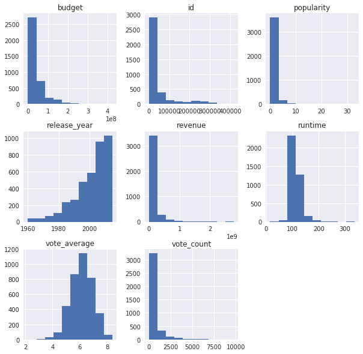

```python
#Visualize the data distribution by columns to examine it deeper.
tmdb_df.hist(figsize = (10, 10));
```

lets take a close look at some distribution

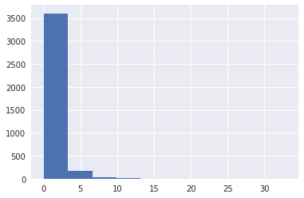

```python
#popularity distribution
tmdb_df['popularity'].hist();
```

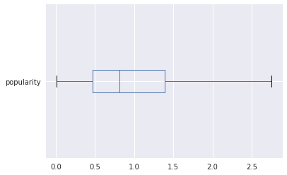

```python
tmdb_df.boxplot('popularity',vert=False,showfliers=False);
```

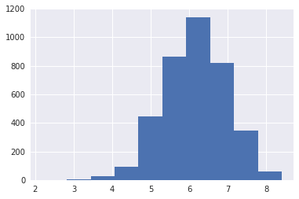

```python
#vote_average distribution
tmdb_df['vote_average'].hist();
```

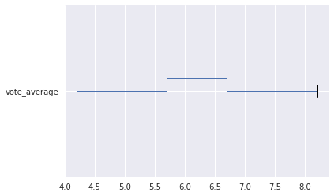

```python
tmdb_df.boxplot('vote_average',vert=False,showfliers=False);
```

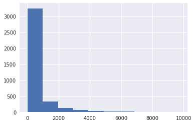

```python
#vote_count distribution
tmdb_df['vote_count'].hist();
```

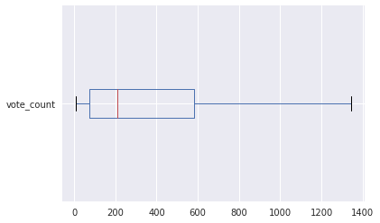

```python
tmdb_df.boxplot('vote_count',vert=False,showfliers=False);
```

> From histograms and box plots we can notice that most of movies has an average rating between 5.5 and 7 . Also we noticed that most of movies has received a number of votes between 10 and 1000.

### lets check now the relations between variables

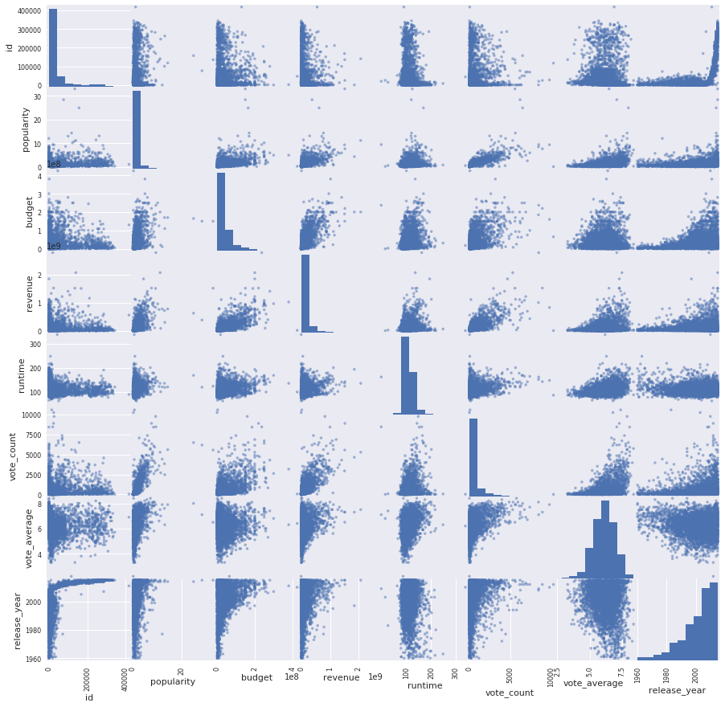

```python
#an overview on all relations by scatter matrix plot
pd.plotting.scatter_matrix(tmdb_df, figsize = (15,15));
```

#### lets take a close look

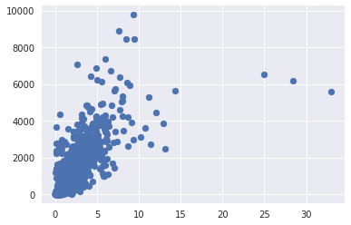

```python
# relation between popularity and vote count
plt.scatter(tmdb_df.popularity, tmdb_df.vote_count);
```

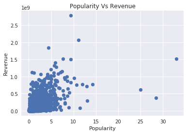

```python
# relation between popularity and revenue
plt.scatter(tmdb_df.popularity, tmdb_df.revenue);
plt.title('Popularity Vs Revenue')
plt.xlabel('Popularity')
plt.ylabel('Revenue');
```

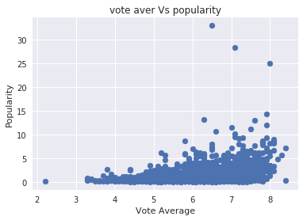

```python
# relation between vote average and poularity
plt.scatter(tmdb_df.vote_average, tmdb_df.popularity);
plt.title('vote aver Vs popularity')
plt.xlabel('Vote Average')
plt.ylabel('Popularity');
```

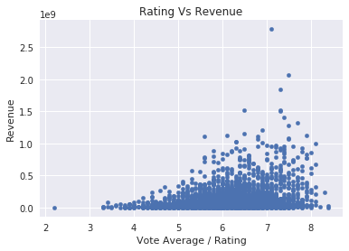

```python
# relation between vote aver and revenue
tmdb_df.plot(x='vote_average',y='revenue',kind='scatter')
plt.title('Rating Vs Revenue')
plt.xlabel('Vote Average / Rating')
plt.ylabel('Revenue');
```

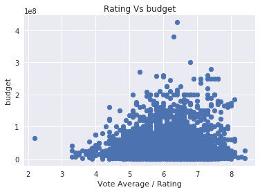

```python
# relation between vote average and budget
plt.scatter(tmdb_df.vote_average, tmdb_df.budget);
plt.title('Rating Vs budget')
plt.xlabel('Vote Average / Rating')
plt.ylabel('budget');
```

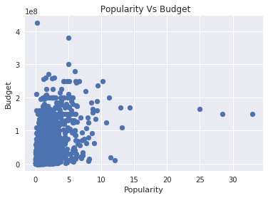

```python
# relation between popularity and budget
plt.scatter(tmdb_df.popularity, tmdb_df.budget);
plt.title(' Popularity Vs Budget')
plt.xlabel('Popularity')
plt.ylabel('Budget');
```

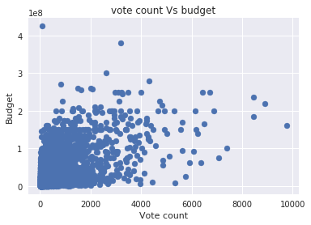

```python
# relation between vote count and budget
plt.scatter(tmdb_df.vote_count, tmdb_df.budget);
plt.title('vote count Vs budget')
plt.xlabel('Vote count')
plt.ylabel('Budget');
```

From previous plots we can answer those questions:

> - Do movies with higher budget are more populare? not always
> - Do movies with higher budget recieve better ratings? no
> - Do vote counts affect popularity and vote ratings? yes

### Research Question 2: What are the most succesful movies(in earnings)?

> To answer this question i need to know the pure gains of every movie then sort all of them to know which movie got the most earnings. First i will make a profit columne from the two columns revenue and budget then sort movies according to profit columne then the top movies will be the most successful.

```python
# First i will make a profit columne from the two columns revenue and budget
tmdb_df['profit'] = tmdb_df['revenue']-tmdb_df['budget']
tmdb_df.dtypes
```

```
id                               int64
popularity                     float64
budget                         float64
revenue                        float64
original_title                  object
cast                            object
director                        object
overview                        object
runtime                        float64
genres                          object
production_companies            object
release_date            datetime64[ns]
vote_count                       int64
vote_average                   float64
release_year                     int64
profit                         float64
dtype: object
```

```python
#converting profit to integer
tmdb_df['profit'] = tmdb_df['profit'].astype(int)
tmdb_df.dtypes
```

[output not shown]

```python
#function to find top 10 for a chosen column which sorted the given column and select the top ten
# then plot the result
def top_ten(col_name,size=10):
    sorted_df = pd.DataFrame(tmdb_df[col_name].sort_values(ascending=False))[:size]
    sorted_df['original_title'] = tmdb_df['original_title']
    plt.figure(figsize=(10,8))
    sns.barplot(x=col_name, y='original_title', data=sorted_df, label=col_name)
    plt.xlabel(col_name)
    plt.ylabel('')
    plt.title('Top 10 Movies in: ' + col_name)
    plt.legend()
```

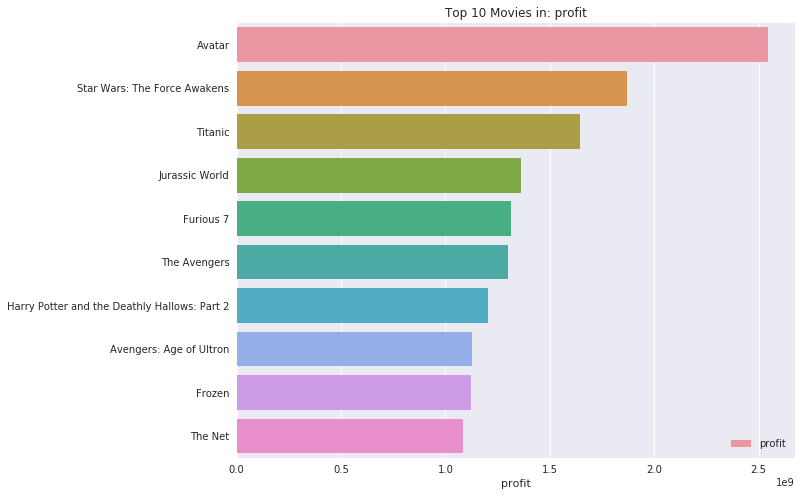

```python
top_ten('profit')
```

### Research Question 3: Who is the Director produced the best movies in 2010?

```python
# Filtering the dataset to movies released in 2010 alone
df_2010=tmdb_df.query('release_year== 2010')
```

```python
#groubing data in 2010 by director and title then calc the film rating
director_rate = df_2010.groupby(['director', 'original_title']).mean().vote_average
```

```python
director_rate
```

```
director                    original_title
Abe Sylvia                  Dirty Girl                                       6.2
Adam Green                  Hatchet II                                       5.1
Adam McKay                  The Other Guys                                   6.1
Alan Poul                   The Back-Up Plan                                 5.7
Albert Hughes|Allen Hughes  The Book of Eli                                  6.5
                                                                            ...
Wes Craven                  My Soul to Take                                  5.2
Will Gluck                  Easy A                                           6.6
William Dear                The Perfect Game                                 5.7
William Monahan             London Boulevard                                 5.5
Zack Snyder                 Legend of the Guardians: The Owls of Ga'Hoole    6.5
Name: vote_average, Length: 177, dtype: float64
```

```python
sort_directors = director_rate.sort_values(ascending=False)
sort_directors.head()
```

```
director           original_title
Christopher Nolan  Inception         7.9
Lucy Walker        Waste Land        7.8
Martin Scorsese    Shutter Island    7.6
Charles Ferguson   Inside Job        7.6
Lee Unkrich        Toy Story 3       7.5
Name: vote_average, dtype: float64
```

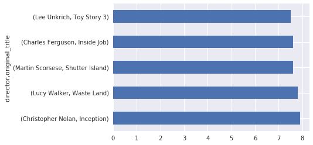

```python
sort_directors.head().plot(kind= 'barh');
```

## Conclusions

> From previous analysis we found some useful information :

#### In first researsh question we could notice that:

> From histograms and box plots we can notice that most of movies has an average rating between 5.5 and 7. Also we noticed that most of movies has received a number of votes between 10 and 1000. From relations plots we noticed that the revenue increases with increasing in Popularity and also between popularity and vote count.

#### Limitations:

> - I found there are alot of missing values need to handle in: imdb_id,homepage, cast, director, tagline, keywords, overview, genres, and production_companies.
> - There are many columns we don't need in our anlyasis like :(imdb_id,tagline,homepage,keywords, budget_adj,revenue_adj)
> - Fortunately, we have just one duplicated value
> - release date column incorrect format.
> - there are movies with zero budget value and zero revenue value, means there values have not been recorded.
> - movies with zero runtime value.

#### From second question we found that:

> The most successfull movies in earnings of all time are:
> - Avatar
> - Starwars :The force awakens
> - Titanic
> - Jurassic world
> - Furious 7
> - The Avengers.

>   > And the first place goes to ... Avatar with 2.5 Billion profit.

#### limitation :

>   > I had to make a new columne with profit values to use it in comparison. I made that columne from by calculating the difference between revenue and budget columns.

#### In third question research :

> We Could get the top five directors with best rating in 2010:

| Director | Movie Name | Rating |
| --- | --- | --- |
| Christopher Nolan | Inception | 7.9 |
| Lucy Walker | Waste Land | 7.8 |
| Martin Scorsese | Shutter Island | 7.6 |
| Charles Ferguson | Inside Job | 7.6 |
| Lee Unkrich | Toy Story 3 | 7.5 |

### References

- [Seaborn library definition](https://seaborn.pydata.org/)
- [Kaggle Data Source](https://www.kaggle.com/tmdb/tmdb-movie-metadata)
- [TMDB Data Base](https://www.themoviedb.org/documentation/api)
- [Prev Analysis 1](https://github.com/antra0497/Udacity--Project-Investigate-TMDB-Movies-Dataset)
- [Prev analysis 2](https://github.com/salahbeeh/Udacity-Investigate-Kaggle-TMDB-movie-dataset-)
- [Prev Analysis 3](https://www.matthewunrue.com/Projects/Udacity/TMDb/Project.html)
- [For Markdown 1](https://www.markdownguide.org/basic-syntax/)
- [For Markdon 2](https://github.com/adam-p/markdown-here/wiki/Markdown-Cheatsheet)

> > Special thanks to Udacity, FWD Community, Juno, and every tutor who helped us learning something making us better. I'm very grateful to all of you.

```python
from subprocess import call
call(['python', '-m', 'nbconvert', 'Investigate_a_Dataset.ipynb'])
```

```
0
```